# Generalized Linear Models

## Probabilities

We can obtain the probability $p=\mbox{Prob(Male)}$ using the following transformation:
$$p = \frac{\mbox{exp}(\alpha + \beta \cdot \mbox{age})}{1 + \mbox{exp}(\alpha + \beta \cdot \mbox{age})}$$

For example, the probabilit of a teaching instructor who is 52 years old being male is

$$p = \frac{\mbox{exp}(\alpha + \beta \cdot \mbox{age})}{1 + \mbox{exp}(\alpha + \beta \cdot \mbox{age})} = \frac{\mbox{exp}(-2.697946 + 0.0629647 \cdot \mbox{52})}{1 + \mbox{exp}(-2.697946 + 0.0629647 \cdot \mbox{52})}$$

which can be computed in R as follows:

```r
p.num <- exp(mod.coef.logodds["(Intercept)", "Estimate"] +
               mod.coef.logodds["age", "Estimate"] * 52)
p.denom <- 1 + p.num
p.num/p.denom
```

```
[1] 0.6401971
```

The `plogis()` function from the `stats` library can also be used to obtain probabilities from the log-odds:

```r
plogis(mod.coef.logodds["(Intercept)", "Estimate"] +
         mod.coef.logodds["age", "Estimate"] * 52)
```

```
[1] 0.6401971
```

Let’s add the probabilities to our data, which is done using the `fitted()` function:

```r
evals.gender <- evals.gender %>%
  mutate(probs.male = fitted(model))
```

**Note*: `predict(model, type = "response")` will also provide the estimated probabilities.

```r
q5 <- evals.gender %>%
  filter(age == 33, gender == "female")
```

**What is the log-odds of a 47 year old instructor being male?**

```r
q6 <- evals.gender %>%
  filter(age == 47, gender == "male")
```

Finally, we can plot the probability of being male using the `geom_smooth()` function by giving `method = "glm"` and `methods.args = list(family = "binomial")` as follows:

```r
evals.gender <- evals.gender %>%
                  mutate(probs.male = fitted(model))

ggplot(data = evals.gender, aes(x = age, y = probs.male)) +
  geom_dotplot(dotsize = 0.6, alpha = 0.2, aes(fill = gender),
               binwidth = 1, stackgroups = TRUE) +
  geom_smooth(method = "glm",
              method.args = list(family = "binomial"),
              se = FALSE) +
  labs(x = "Age", y = "Probability of instructor being male")
```

[output not shown]

**Note**: the ages of all teaching instructors have been superimposed as a dotplot using `geom_dotplot()`.

The `plot_model()` function from the `sjPlot` package can also produce the estimated probabilities by `age` as follows:

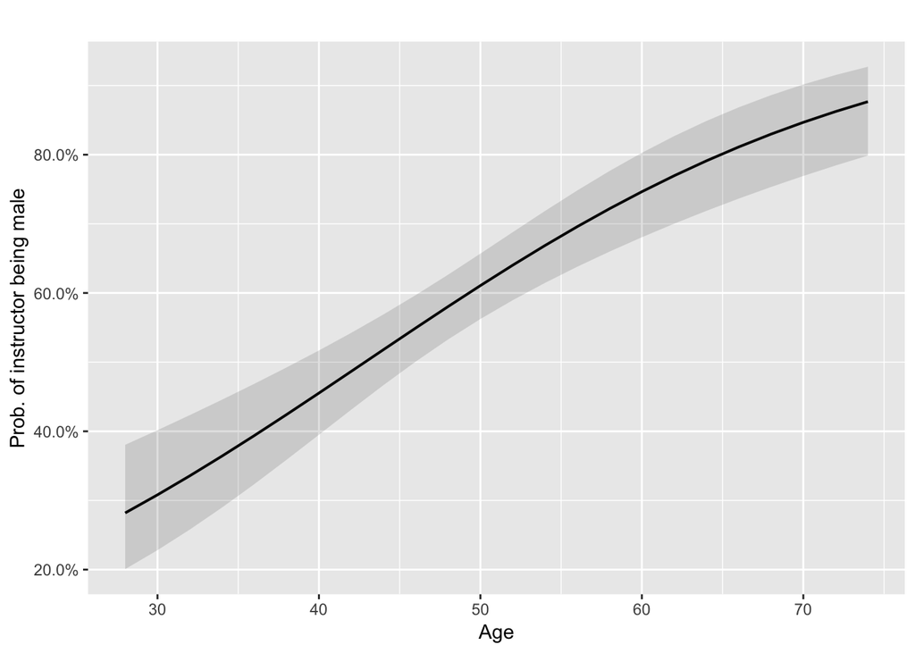

Probability of teaching instructor being male by age

```r
plot_model(model, type = "pred", title = "",
           axis.title = c("Age", "Prob. of instructor being male"))
```